# Exam 1

## Exam 1

#### Question

1. En una clase de antropometría, se midió la estatura (en cm) de un grupo de estudiantes. Los datos obtenidos son:

   **Datos de estaturas**

   | 175 | 166 | 168 |
   | --- | --- | --- |
   | 170 | 170 | 173 |
   | 169 | 170 | 165 |
   | 163 | 170 | 169 |
   | 166 | 170 | 176 |
   | 168 | 174 |  |
   | 170 | 167 |  |
   | 164 | 165 |  |
   | 174 | 165 |  |
   | 167 | 166 |  |

   ¿Cuál diagrama de caja representa correctamente estos datos?

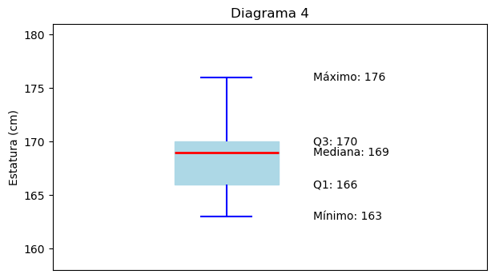

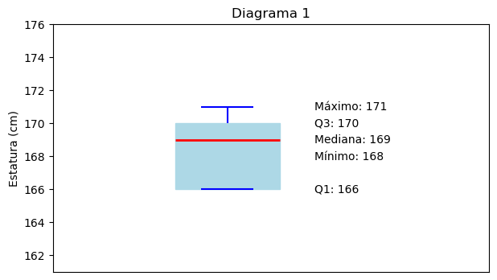

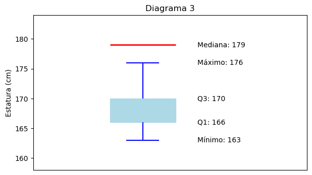

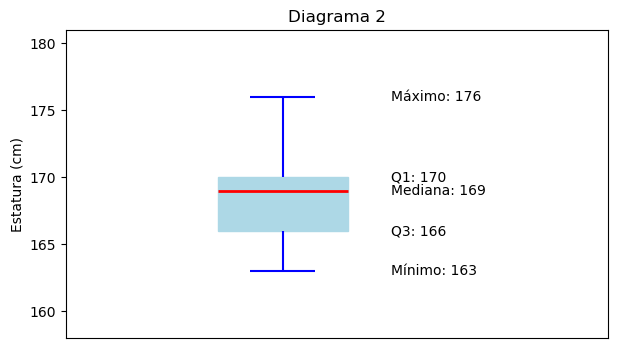

#### Solution

   **Datos de estaturas ordenados**

   | 163 | 168 | 173 |
   | --- | --- | --- |
   | 164 | 168 | 174 |
   | 165 | 169 | 174 |
   | 165 | 169 | 175 |
   | 165 | 170 | 176 |
   | 166 | 170 |  |
   | 166 | 170 |  |
   | 166 | 170 |  |
   | 167 | 170 |  |
   | 167 | 170 |  |

   La opción correcta es aquella cuyo diagrama muestra exactamente estos valores:

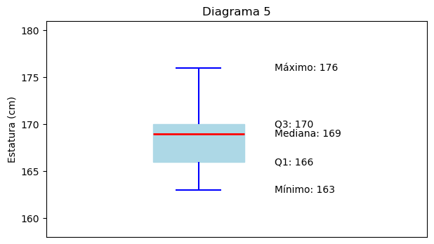

   1. Verdadero
   2. Falso
   3. Falso
   4. Falso

#### Question

2. En una clase de antropometría, se midió la estatura (en cm) de un grupo de estudiantes. Los datos obtenidos son:

   **Datos de estaturas**

   | 172 |
   | --- |
   | 164 |
   | 154 |
   | 165 |
   | 162 |
   | 170 |
   | 148 |
   | 160 |
   | 154 |
   | 172 |

   ¿Cuál diagrama de caja representa correctamente estos datos?

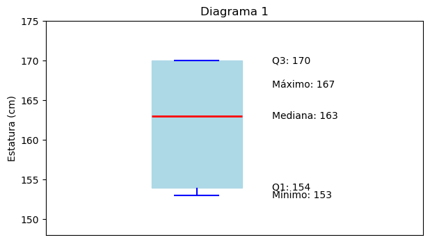

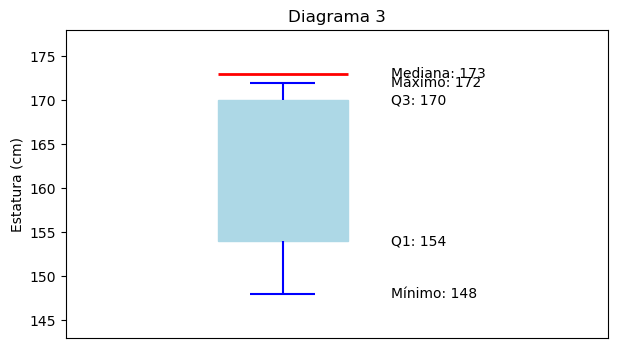

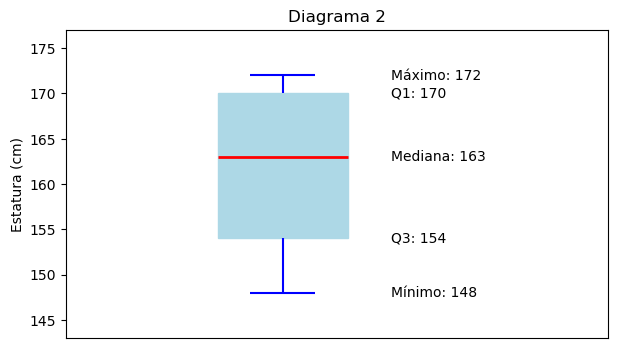

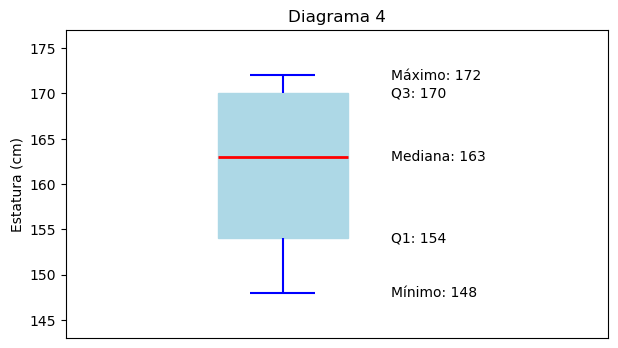

#### Solution

   **Datos de estaturas ordenados**

   | 148 |
   | --- |
   | 154 |
   | 154 |
   | 160 |
   | 162 |
   | 164 |
   | 165 |
   | 170 |
   | 172 |
   | 172 |

   La opción correcta es aquella cuyo diagrama muestra exactamente estos valores:

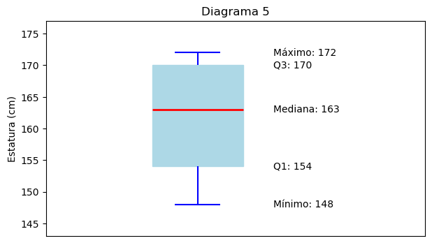

   1. Falso
   2. Falso
   3. Falso
   4. Verdadero

#### Question

3. En una clase de antropometría, se midió la estatura (en cm) de un grupo de estudiantes. Los datos obtenidos son:

   **Datos de estaturas**

   | 152 | 180 | 173 |
   | --- | --- | --- |
   | 161 | 188 | 158 |
   | 172 | 165 | 152 |
   | 180 | 184 | 152 |
   | 182 | 172 |  |
   | 154 | 169 |  |
   | 163 | 169 |  |
   | 175 | 163 |  |
   | 154 | 177 |  |
   | 169 | 172 |  |

   ¿Cuál diagrama de caja representa correctamente estos datos?

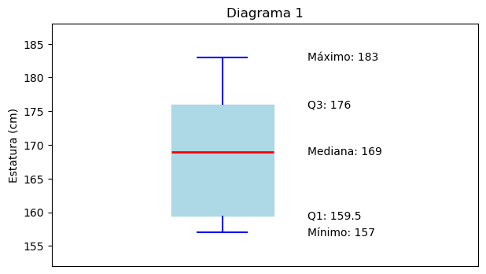

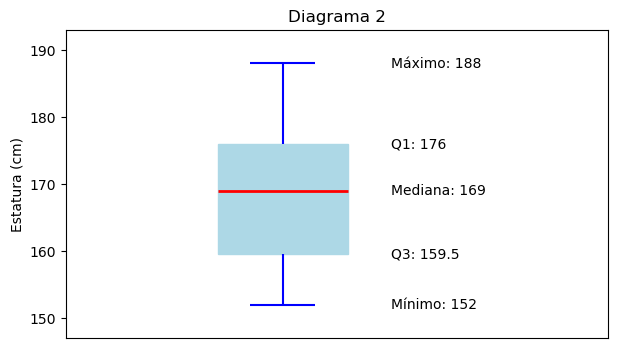

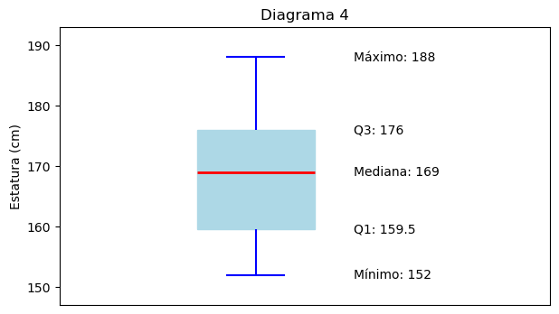

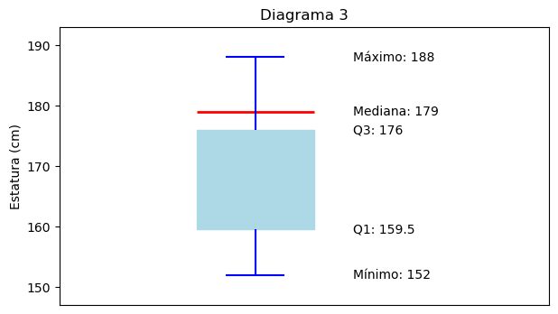

#### Solution

   **Datos de estaturas ordenados**

   | 152 | 169 | 180 |
   | --- | --- | --- |
   | 152 | 169 | 182 |
   | 152 | 169 | 184 |
   | 154 | 172 | 188 |
   | 154 | 172 |  |
   | 158 | 172 |  |
   | 161 | 173 |  |
   | 163 | 175 |  |
   | 163 | 177 |  |
   | 165 | 180 |  |

   La opción correcta es aquella cuyo diagrama muestra exactamente estos valores:

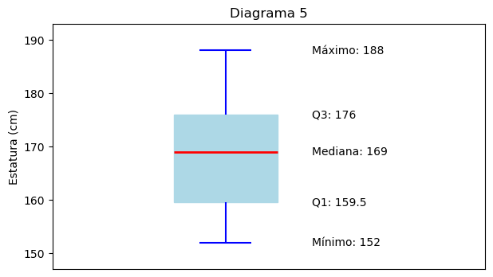

   1. Falso
   2. Falso
   3. Verdadero
   4. Falso

#### Question

4. En una clase de antropometría, se midió la estatura (en cm) de un grupo de estudiantes. Los datos obtenidos son:

   **Datos de estaturas**

   | 169 | 164 | 164 |
   | --- | --- | --- |
   | 170 | 172 |  |
   | 166 | 172 |  |
   | 171 | 170 |  |
   | 166 | 167 |  |
   | 168 | 165 |  |
   | 171 | 168 |  |
   | 166 | 166 |  |
   | 171 | 171 |  |
   | 167 | 172 |  |

   ¿Cuál diagrama de caja representa correctamente estos datos?

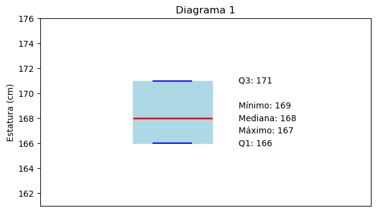

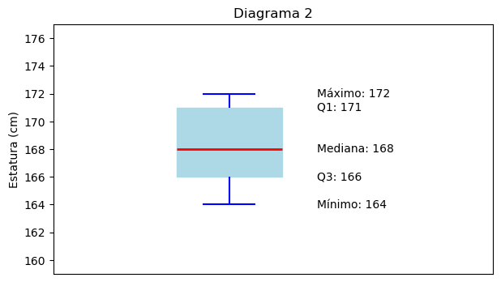

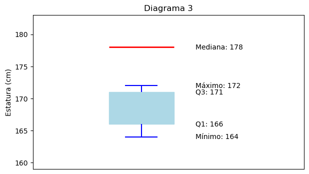

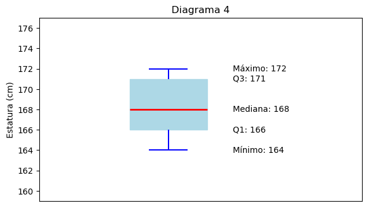

#### Solution

   **Datos de estaturas ordenados**

   | 164 | 168 | 172 |
   | --- | --- | --- |
   | 164 | 169 |  |
   | 165 | 170 |  |
   | 166 | 170 |  |
   | 166 | 171 |  |
   | 166 | 171 |  |
   | 166 | 171 |  |
   | 167 | 171 |  |
   | 167 | 172 |  |
   | 168 | 172 |  |

   La opción correcta es aquella cuyo diagrama muestra exactamente estos valores:

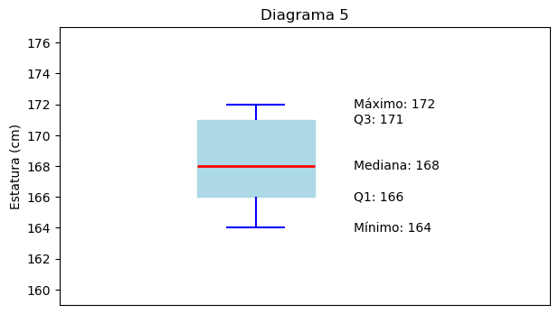

   1. Falso
   2. Falso
   3. Falso
   4. Verdadero

#### Question

5. En una clase de antropometría, se midió la estatura (en cm) de un grupo de estudiantes. Los datos obtenidos son:

   **Datos de estaturas**

   | 153 | 159 | 153 |
   | --- | --- | --- |
   | 167 | 158 | 172 |
   | 162 | 176 |  |
   | 170 | 158 |  |
   | 175 | 178 |  |
   | 172 | 164 |  |
   | 166 | 173 |  |
   | 179 | 158 |  |
   | 166 | 177 |  |
   | 175 | 163 |  |

   ¿Cuál diagrama de caja representa correctamente estos datos?

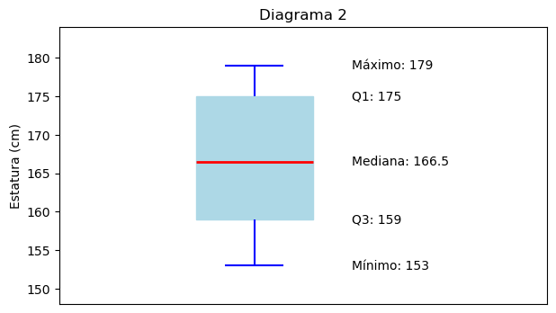

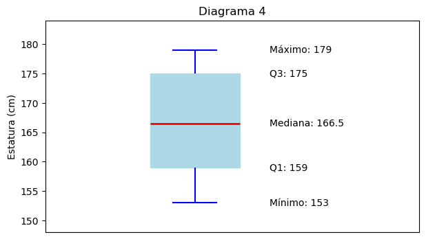

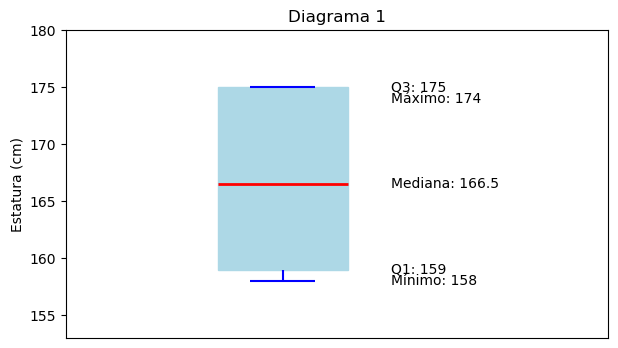

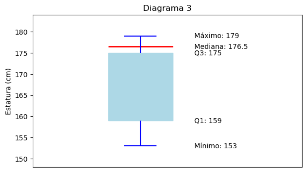

#### Solution

   **Datos de estaturas ordenados**

   | 153 | 166 | 178 |
   | --- | --- | --- |
   | 153 | 167 | 179 |
   | 158 | 170 |  |
   | 158 | 172 |  |
   | 158 | 172 |  |
   | 159 | 173 |  |
   | 162 | 175 |  |
   | 163 | 175 |  |
   | 164 | 176 |  |
   | 166 | 177 |  |

   La opción correcta es aquella cuyo diagrama muestra exactamente estos valores:

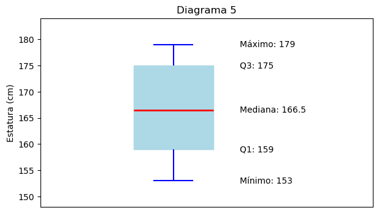

   1. Falso
   2. Verdadero
   3. Falso
   4. Falso

#### Question

6. En una clase de antropometría, se midió la estatura (en cm) de un grupo de estudiantes. Los datos obtenidos son:

   **Datos de estaturas**

   | 164 | 166 |
   | --- | --- |
   | 161 |  |
   | 164 |  |
   | 154 |  |
   | 162 |  |
   | 169 |  |
   | 160 |  |
   | 155 |  |
   | 156 |  |
   | 165 |  |

   ¿Cuál diagrama de caja representa correctamente estos datos?

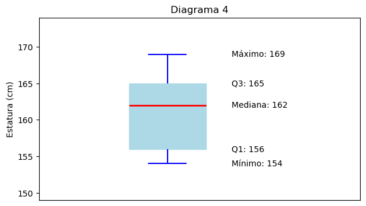

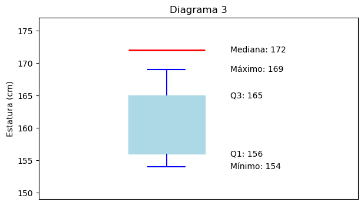

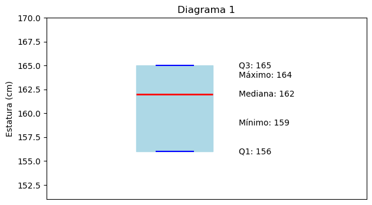

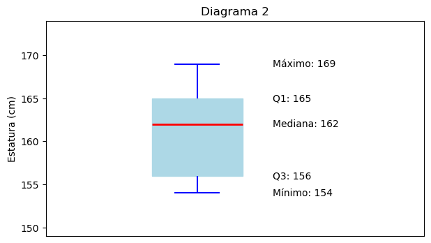

#### Solution

   **Datos de estaturas ordenados**

   | 154 | 169 |
   | --- | --- |
   | 155 |  |
   | 156 |  |
   | 160 |  |
   | 161 |  |
   | 162 |  |
   | 164 |  |
   | 164 |  |
   | 165 |  |
   | 166 |  |

   La opción correcta es aquella cuyo diagrama muestra exactamente estos valores:

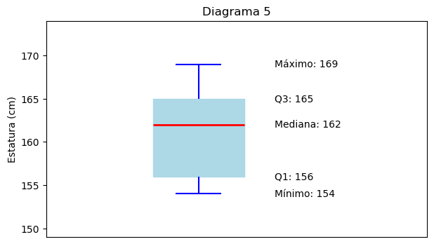

   1. Verdadero
   2. Falso
   3. Falso
   4. Falso

#### Question

7. En una clase de antropometría, se midió la estatura (en cm) de un grupo de estudiantes. Los datos obtenidos son:

   **Datos de estaturas**

   | 180 | 163 | 180 |
   | --- | --- | --- |
   | 171 | 169 | 182 |
   | 173 | 176 |  |
   | 167 | 155 |  |
   | 185 | 162 |  |
   | 156 | 163 |  |
   | 168 | 163 |  |
   | 177 | 176 |  |
   | 176 | 168 |  |
   | 159 | 169 |  |

   ¿Cuál diagrama de caja representa correctamente estos datos?

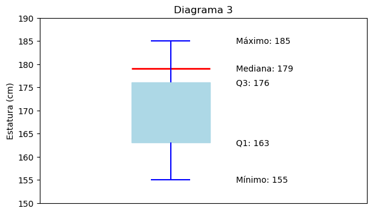

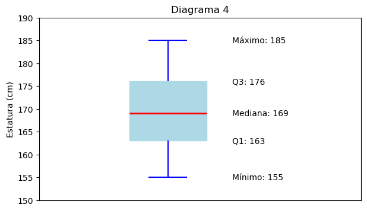

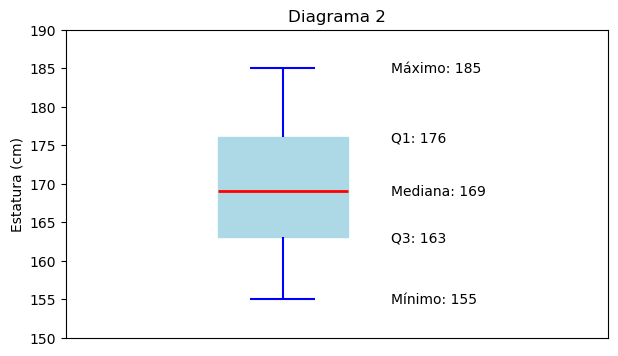

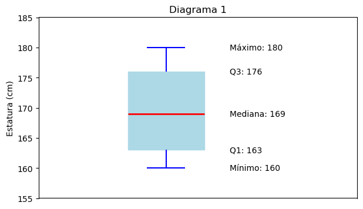

#### Solution

   **Datos de estaturas ordenados**

   | 155 | 169 | 182 |
   | --- | --- | --- |
   | 156 | 169 | 185 |
   | 159 | 171 |  |
   | 162 | 173 |  |
   | 163 | 176 |  |
   | 163 | 176 |  |
   | 163 | 176 |  |
   | 167 | 177 |  |
   | 168 | 180 |  |
   | 168 | 180 |  |

   La opción correcta es aquella cuyo diagrama muestra exactamente estos valores:

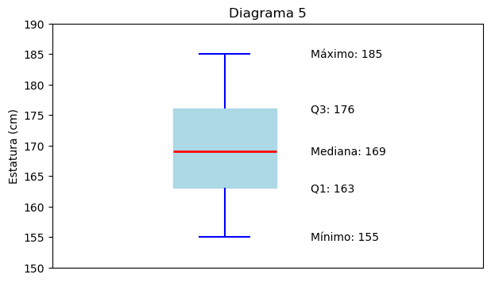

   1. Falso
   2. Verdadero
   3. Falso
   4. Falso

#### Question

8. En una clase de antropometría, se midió la estatura (en cm) de un grupo de estudiantes. Los datos obtenidos son:

   **Datos de estaturas**

   | 168 | 186 |
   | --- | --- |
   | 171 | 174 |
   | 170 | 187 |
   | 180 | 181 |
   | 175 | 175 |
   | 171 | 182 |
   | 180 | 181 |
   | 163 |  |
   | 179 |  |
   | 167 |  |

   ¿Cuál diagrama de caja representa correctamente estos datos?

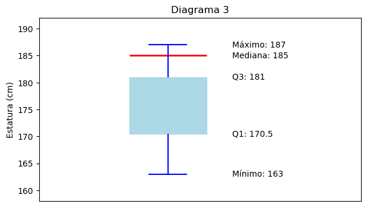

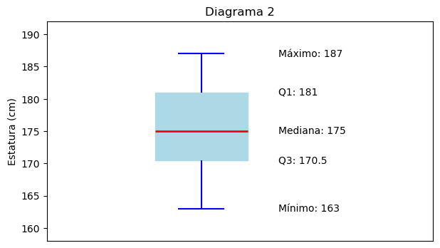

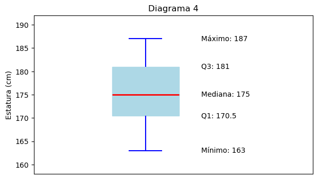

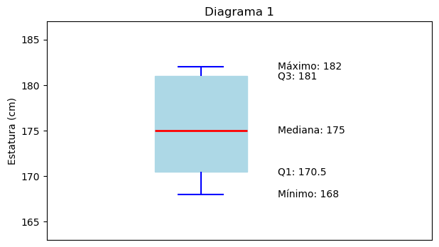

#### Solution

   **Datos de estaturas ordenados**

   | 163 | 180 |
   | --- | --- |
   | 167 | 180 |
   | 168 | 181 |
   | 170 | 181 |
   | 171 | 182 |
   | 171 | 186 |
   | 174 | 187 |
   | 175 |  |
   | 175 |  |
   | 179 |  |

   La opción correcta es aquella cuyo diagrama muestra exactamente estos valores:

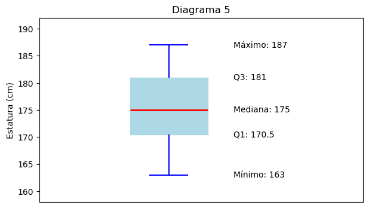

   1. Falso
   2. Falso
   3. Verdadero
   4. Falso

#### Question

9. En una clase de antropometría, se midió la estatura (en cm) de un grupo de estudiantes. Los datos obtenidos son:

   **Datos de estaturas**

   | 167 | 175 | 181 |
   | --- | --- | --- |
   | 177 | 177 | 177 |
   | 174 | 169 |  |
   | 169 | 173 |  |
   | 179 | 166 |  |
   | 166 | 180 |  |
   | 176 | 172 |  |
   | 172 | 175 |  |
   | 168 | 165 |  |
   | 169 | 170 |  |

   ¿Cuál diagrama de caja representa correctamente estos datos?

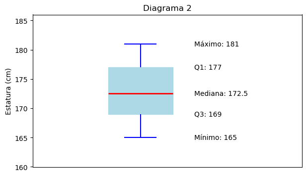

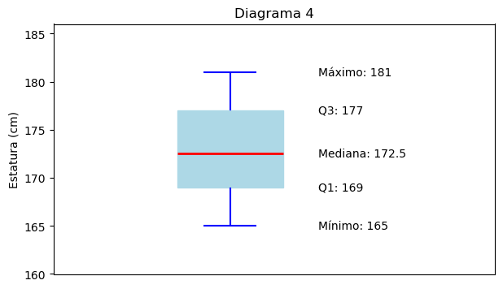

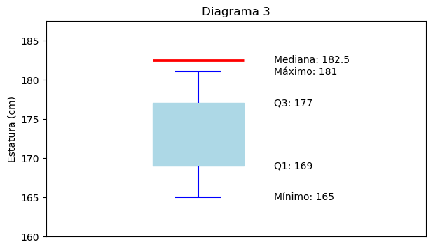

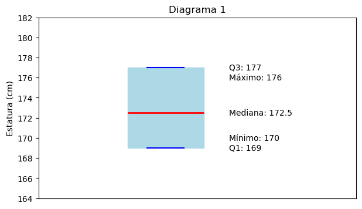

#### Solution

   **Datos de estaturas ordenados**

   | 165 | 172 | 180 |
   | --- | --- | --- |
   | 166 | 173 | 181 |
   | 166 | 174 |  |
   | 167 | 175 |  |
   | 168 | 175 |  |
   | 169 | 176 |  |
   | 169 | 177 |  |
   | 169 | 177 |  |
   | 170 | 177 |  |
   | 172 | 179 |  |

   La opción correcta es aquella cuyo diagrama muestra exactamente estos valores:

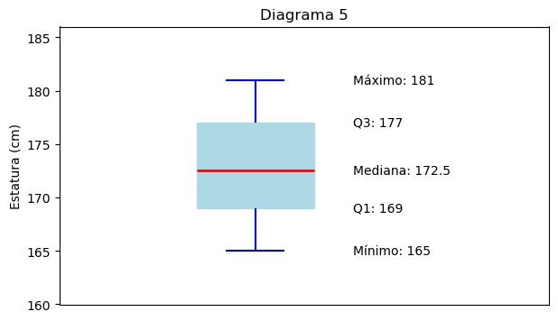

   1. Falso
   2. Verdadero
   3. Falso
   4. Falso

#### Question

10. En una clase de antropometría, se midió la estatura (en cm) de un grupo de estudiantes. Los datos obtenidos son:

    **Datos de estaturas**

    | 159 | 153 | 164 |
    | --- | --- | --- |
    | 166 | 154 | 154 |
    | 165 | 149 | 151 |
    | 152 | 152 | 151 |
    | 154 | 160 | 157 |
    | 159 | 155 |  |
    | 149 | 171 |  |
    | 155 | 154 |  |
    | 157 | 157 |  |
    | 161 | 170 |  |

    ¿Cuál diagrama de caja representa correctamente estos datos?

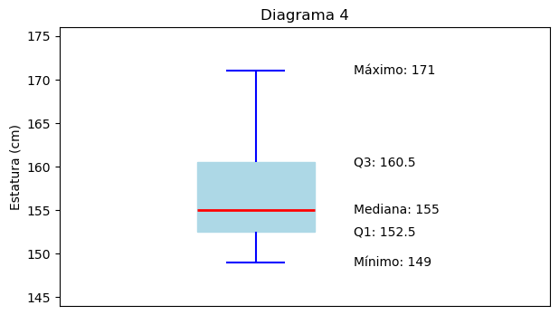

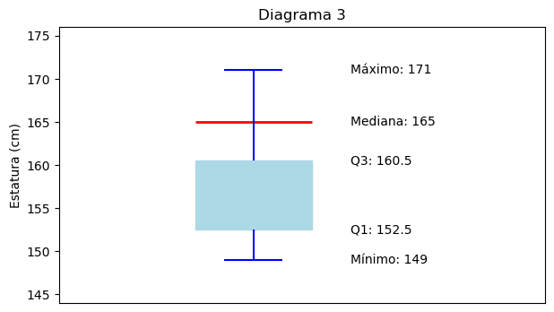

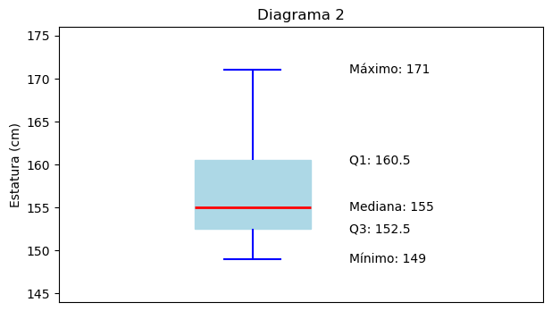

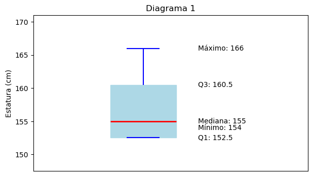

#### Solution

    **Datos de estaturas ordenados**

    | 149 | 154 | 164 |
    | --- | --- | --- |
    | 149 | 155 | 165 |
    | 151 | 155 | 166 |
    | 151 | 157 | 170 |
    | 152 | 157 | 171 |
    | 152 | 157 |  |
    | 153 | 159 |  |
    | 154 | 159 |  |
    | 154 | 160 |  |
    | 154 | 161 |  |

    La opción correcta es aquella cuyo diagrama muestra exactamente estos valores:

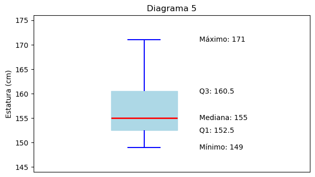

    1. Verdadero
    2. Falso
    3. Falso
    4. Falso